# A closer look at the ggpubr package for R

# Prerequisites

Load required packages:

```r
library(pacman)
p_load(tidyverse, rio, ggpubr, rstatix, scales, flextable)
```

# Introduction

If you are using R there is a very good chance you are creating plots using the `ggplot2` package.

What you might not know is that there are now over 100 registered extensions available which support and/or extend `ggplot2`[^1].

One of my favourites is `ggpubr` - a package that provides some easy-to-use functions for creating clean and publication ready plots.

Let’s see what `ggpubr` has to offer using the [sports car price](https://www.kaggle.com/datasets/rkiattisak/sports-car-prices-dataset) data set.

# Are faster sports cars more expensive?

[figure not shown]

The question we want to answer is will spending more money on a sports car gets you a faster car?

To answer this question we will create a plot and leverage some of the functions provided by `ggpubr`.

Start by downloading and importing the data set:

```r
data <- rio::import("sport_car_price.csv") %>%
  as_tibble()
flextable::flextable(data %>% head)
```

| Car Make | Car Model | Year | Engine Size (L) | Horsepower | Torque (lb-ft) | 0-60 MPH Time (seconds) | Price (in USD) |
| --- | --- | --- | --- | --- | --- | --- | --- |
| Porsche | 911 | 2,022 | 3 | 379 | 331 | 4 | 101,200 |
| Lamborghini | Huracan | 2,021 | 5.2 | 630 | 443 | 2.8 | 274,390 |
| Ferrari | 488 GTB | 2,022 | 3.9 | 661 | 561 | 3 | 333,750 |
| Audi | R8 | 2,022 | 5.2 | 562 | 406 | 3.2 | 142,700 |
| McLaren | 720S | 2,021 | 4 | 710 | 568 | 2.7 | 298,000 |
| BMW | M8 | 2,022 | 4.4 | 617 | 553 | 3.1 | 130,000 |

Then clean up the data and convert time taken to reach 60 mph (in seconds) from a continuous to a categorical variable:

```r
data <-
  data %>% filter(!grepl("Electric", `Engine Size (L)`)) %>%
  filter(`Engine Size (L)` != "N/A") %>%
  filter(`Engine Size (L)` != "0") %>%
  filter(`Engine Size (L)` != "-") %>%
   filter(!grepl("Hybrid", `Engine Size (L)`)) %>%
  distinct(`Car Make`,`Car Model`,Year,`Engine Size (L)`,Horsepower, `Torque (lb-ft)`, .keep_all = TRUE)

data <- data %>%
  mutate(across(everything(), ~str_replace_all(., ",","")))

data <- data %>%
  mutate(across(c(`Price (in USD)`,`Horsepower`, `Torque (lb-ft)`, `Engine Size (L)`, `0-60 MPH Time (seconds)`),
         as.numeric))

data <- data %>%
  mutate(`time(0-60mph)`=  cut(`0-60 MPH Time (seconds)`, breaks = c(2, 2.9, 4 , Inf),
     labels = c("< 3", "3-4", "> 4"),
     include.lowest = TRUE))

data <- data %>%
  rename(price = `Price (in USD)`)

flextable::flextable(data %>%
                       select(-`Engine Size (L)`, -Horsepower, -`Torque (lb-ft)`, -`0-60 MPH Time (seconds)`) %>%
                       head())%>%
  align_text_col(align = "right") %>%
  flextable::set_table_properties(layout = "autofit",  width = 1)
```

| Car Make | Car Model | Year | price | time(0-60mph) |
| --- | --- | --- | --- | --- |
| Porsche | 911 | 2022 | 101,200 | 3-4 |
| Lamborghini | Huracan | 2021 | 274,390 | < 3 |
| Ferrari | 488 GTB | 2022 | 333,750 | 3-4 |
| Audi | R8 | 2022 | 142,700 | 3-4 |
| McLaren | 720S | 2021 | 298,000 | < 3 |
| BMW | M8 | 2022 | 130,000 | 3-4 |

Then create boxplots comparing the price of the 0-to-60 mph groups using `ggplot2` basic settings:

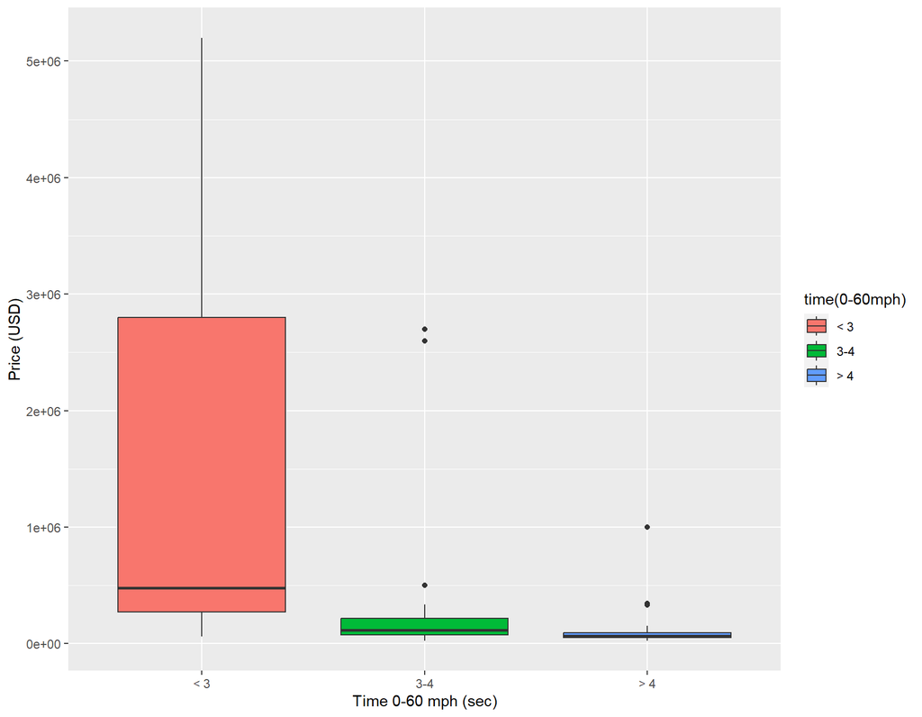

```r
plot <-
  ggplot(data, aes(x=`time(0-60mph)`, y=price)) +
  geom_boxplot(aes( fill = `time(0-60mph)`)) +
  ylab("Price (USD)") +
  xlab("Time 0-60 mph (sec)")

plot
```

The default `ggplot2` look and feel is OK, but could definitely be improved.

This is where `ggpubr` can help.

### Theme

First add the `theme_pubr()` theme to the plot:

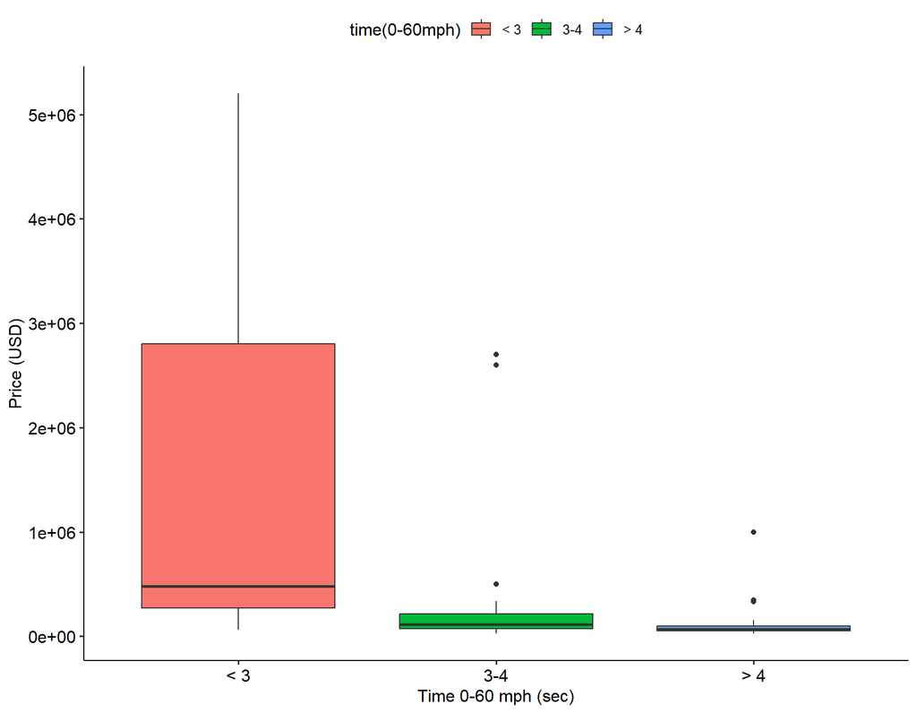

```r
plot <- plot + ggpubr::theme_pubr()
plot
```

Then add the colour palette taken from the New England Journal of Medicine with the `set_palette` function:

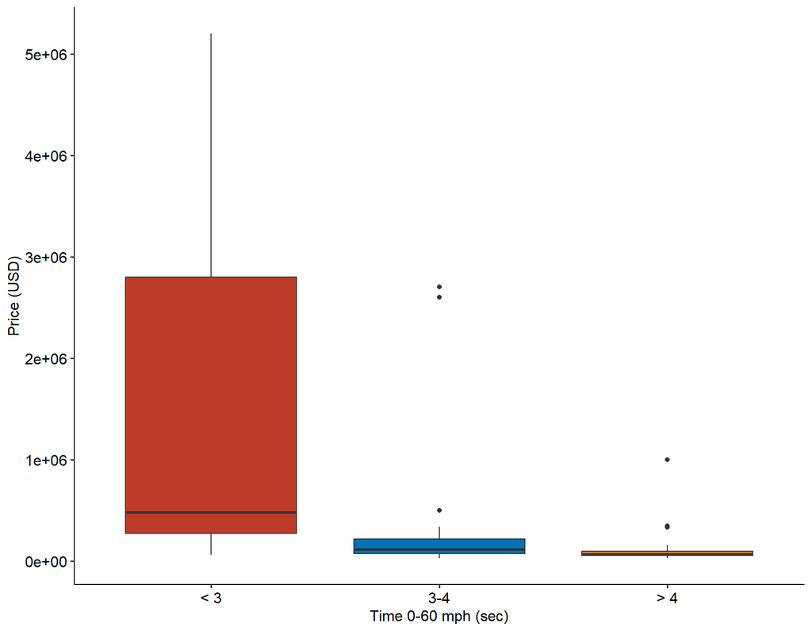

```r
plot <- plot %>%
  ggpubr::set_palette(palette = "nejm") +
  theme(legend.position = 'none')

plot
```

This is a much better looking plot, but the price is in scientific notation and the price range across groups is so large that it is making the boxplots appear compressed.  
Let’s further improve the plot.

## Scales

Using the `scales` package, set the y-axis to a logarithmic scale and convert it to dollar labels:

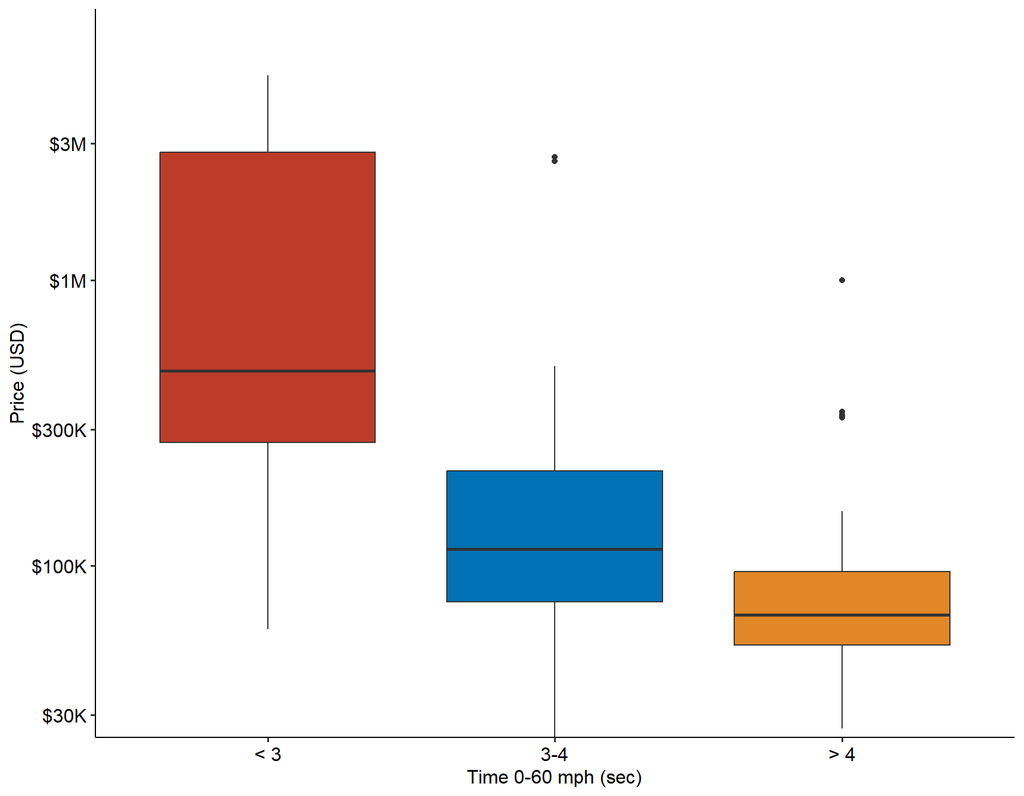

```r
plot <- plot +
  scale_y_continuous(
    trans = 'log10',
    labels = scales::label_dollar(scale_cut = cut_short_scale()
                                  ),
    breaks = scales::breaks_log(n = 5),
    expand = expansion(mult = c(0, 0.1))
    )

plot
```

## Statistics

We can also improve the plot by adding statistics.  
In combination with the `rstatix` package, `ggpubr` can make adding statistical labels to a plot relatively easy.

To add statistics, use the `t_test` function from the `rstatix` package to create a data frame with the comparisons required[^2]:

```r
stat_test <- data %>%
  rename(time = `time(0-60mph)`) %>%
  rstatix::t_test(price ~ time, detailed = TRUE) %>%
  rstatix::adjust_pvalue(method = "bonferroni") %>%
  rstatix::add_significance("p.adj")

flextable::flextable(stat_test)
```

| estimate | estimate1 | estimate2 | .y. | group1 | group2 | n1 | n2 | statistic | p | df | conf.low | conf.high | method | alternative | p.adj | p.adj.signif |
| --- | --- | --- | --- | --- | --- | --- | --- | --- | --- | --- | --- | --- | --- | --- | --- | --- |
| 1,116,868.26 | 1,305,436.8 | 188,568.5 | price | < 3 | 3-4 | 76 | 173 | 6.979559 | 0.0000000008180 | 78.99424 | 798,356.27 | 1,435,380.3 | T-test | two.sided | 0.0000000024540 |  |
| 1,192,797.13 | 1,305,436.8 | 112,639.6 | price | < 3 | > 4 | 76 | 66 | 7.506716 | 0.0000000000912 | 76.81129 | 876,379.71 | 1,509,214.5 | T-test | two.sided | 0.0000000002736 |  |
| 75,928.87 | 188,568.5 | 112,639.6 | price | 3-4 | > 4 | 173 | 66 | 2.449132 | 0.0150000000000 | 235.15664 | 14,851.02 | 137,006.7 | T-test | two.sided | 0.0450000000000 |  |

We can now add the significance values to our plot:

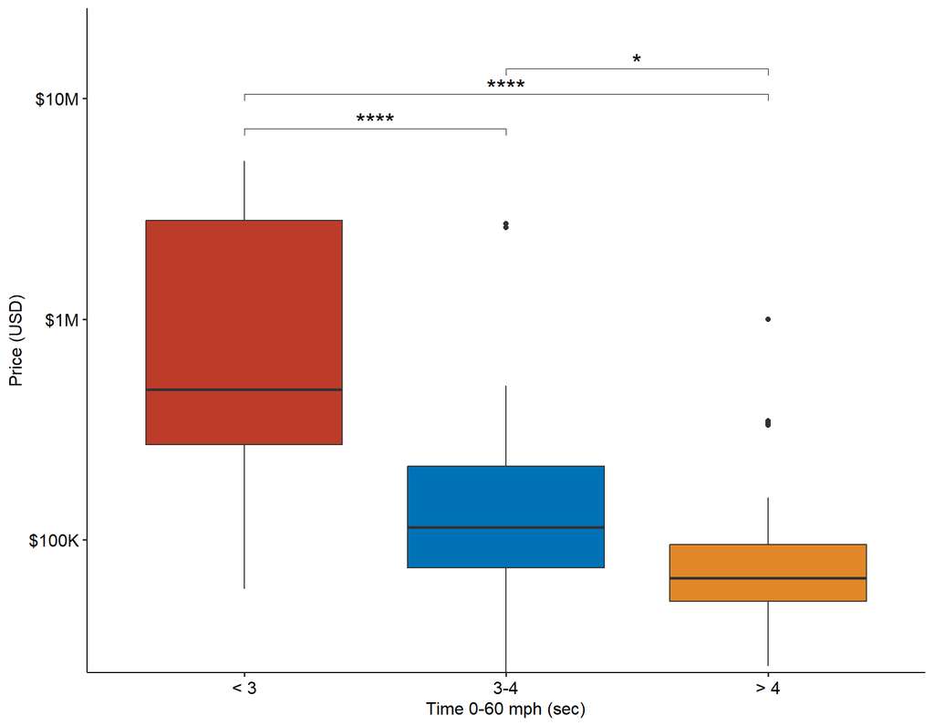

```r
# Add p-values onto the box plots
stat_test <-
  stat_test %>%
  add_y_position(y.trans = log10,
                 step.increase = 0.5)

plot <- plot +
  stat_pvalue_manual(
  stat_test,
  label = "{p.adj.signif}",
  tip.length = 0.005,
  size = 6
  )

plot
```

Now make some final adjustments to the plot[^3]:

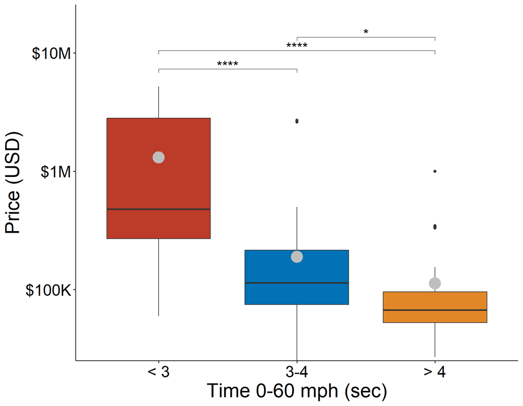

```r
f1 <- function(x) {
  log10(mean(10 ^ x))
}

plot <- plot +
  stat_summary(fun.y = f1, colour = 'grey', size = 1.5) +
  theme(axis.text = element_text(size = 20),
        axis.title = element_text(size = 24))
plot
```

And there we have a really clean looking plot that is easy to read and shows statistical significance.

# Conclusion

`ggpubr` is a fantastic extension to `ggplot2` and makes it easy to turn good plots into *great* plots.  
So does spending more money on a sports car get you a faster car?

Thanks to `ggpubr`, we can see that on average the > 4 second cars are the least expensive, the 3-4 seconds cars are in the middle, and the < 3 seconds cars are the most expensive.  
Thus, spending more money on a sports car does appear to buy you a faster car.

## Footnotes

[^1]: [ggplot2 extensions gallery](https://exts.ggplot2.tidyverse.org/gallery/)
[^2]: I [adjusted the alpha (α) level](https://www.statology.org/bonferroni-correction/) so that the probability of committing a type I error is controlled for. I also had to rename the time(0-60mph) variable to time. This is because the `t_test` function could not find the variable when it was input with back ticks (`) which is the only way I know how when there is a numeric value within the name.
[^3]: Increase the axis text and title size and add the average price to the boxplot represented as a grey dot.